# Validação de Modelos

Análise de dados com modelos lineares em R

Nicholas A. C. Marino

github.com/nacmarino/metodosR

## Recapitulando

- Nós estamos trabalhando com o conjunto de dados `ilhas`;
- A seleção de modelos sugere que a riqueza de espécies (log10) é bem descrita pela variáveis:
  - área da ilha - contínua, log10
  - tipo de ilha - categórica, 2 níveis (oceanica vs costeira)
  - tamanho do arquipelago - categórica, 3 níveis (pequeno vs médio vs grande)
- Outra variáveis podem contribuir, mas aparentemente são menos importantes.

## Carregando dados

```r
ilhas <- read.table("../model_selection/dados/ilhas.txt", header = TRUE)
str(ilhas)
```

```
## 'data.frame':    80 obs. of  12 variables:
##  $ ID           : Factor w/ 80 levels "ilha_1","ilha_10",..: 1 2 3 4 5 6 7 8 9 10 ...
##  $ ilha         : Factor w/ 2 levels "costeira","oceanica": 1 1 1 2 1 2 1 2 2 1 ...
##  $ arquipelago  : Factor w/ 3 levels "grande","medio",..: 2 2 3 3 2 2 1 1 3 2 ...
##  $ riqueza      : int  21 27 23 10 34 13 43 12 13 32 ...
##  $ area         : num  1.51 22.43 41.06 2134.73 1004.75 ...
##  $ produtividade: num  1.57 4.56 2.19 2012.82 244.14 ...
##  $ populacao    : num  268 259 281 145 516 ...
##  $ habitat      : int  2 2 3 5 4 3 2 3 4 3 ...
##  $ montanha     : Factor w/ 2 levels "nao","sim": 1 1 2 2 2 2 2 2 2 2 ...
##  $ mamiferos    : int  7 9 10 6 13 3 9 3 5 11 ...
##  $ temperatura  : num  24.2 21.8 18.3 11.4 23.9 ...
##  $ precipitacao : num  2125 1624 1995 1656 1497 ...
```

## Recriando o modelo selecionado

```r
modelo1 <- glm(log10(riqueza) ~ log10(area) + ilha + arquipelago, data = ilhas)
modelo1
```

```
##
## Call:  glm(formula = log10(riqueza) ~ log10(area) + ilha + arquipelago,
##     data = ilhas)
##
## Coefficients:
##        (Intercept)         log10(area)        ilhaoceanica
##             1.4723              0.1452             -0.4730
##   arquipelagomedio  arquipelagopequeno
##            -0.1879             -0.3912
##
## Degrees of Freedom: 79 Total (i.e. Null);  75 Residual
## Null Deviance:       9.073
## Residual Deviance: 0.8555    AIC: -124
```

## Diagnóstico do Modelo

### O que queremos com um modelo é que os valores **ajustados** batam de forma precisa com os valores **observados** da variável resposta, de forma que possamos **predizer** os valores da nossa variável resposta de acordo com novos valores das variáveis preditoras.

## Diagnóstico do Modelo

### Essa ideia é a base para a validação e o dignóstico de modelos: processo para verificar a adequação do modelo aos dados, além da conformidade com pressupostos estatísticos e identificação de observações tendenciosas.

## Validação de Modelos | Um exemplo

- Faça download deste conjunto de dados e rode as linhas de comando.

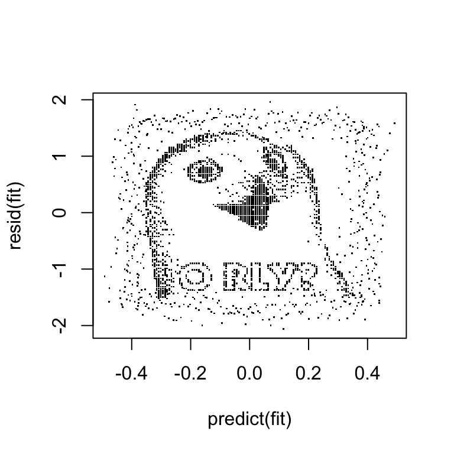

```r
# http://www4.stat.ncsu.edu/~stefanski/NSF_Supported/
# Hidden_Images/orly_owl_files/orly_owl_Lin_4p_5_flat.txt
owl <- read.table("http://www4.stat.ncsu.edu/~stefanski/NSF_Supported/Hidden_Images/orly_owl_files/orly_owl_Lin_4p_5_flat.txt", header = FALSE)
fit <- lm(V1 ~ . - 1, data = owl); plot(predict(fit), resid(fit), pch = '.')
```

## Validação de Modelos | O que buscamos?

- Os valores **ajustados** pelo modelo batem com os valores **observados**?
- Os resíduos da análise seguem a **distribuição normal**?
  - Erros para mais “anulam” erros para menos
  - Pode ser mais importante do que a normalidade da própria variável resposta
  - Não deve existir relação entre a distribuição dos resíduos e a variável **ajustada**
- Os resíduos da análise possuem variância homogênea (*homocedasticidade* vs *heterocedasticidade*)?
  - Entre grupos de uma variável categórica
  - Ao longo do gradiente de uma variável contínua

## Validação de Modelos | O que buscamos?

- As variáveis preditoras são independentes umas das outras (não existe *colinearidade*)?
- O modelo está livre de observações que “puxam” os seus resultados (*leverage*)?
- As observações são independentes?
  - Uma observação por unidade experimentail e/ou indivíduo
  - No espaço
  - No tempo

## Valores Ajustados vs Observados

- Uma das primeiras coisas a se fazer é verificar se existe boa relação entre valores **ajustados** e os **observados**.
- **O que você busca?**: uma relação muito próxima de 1:1.

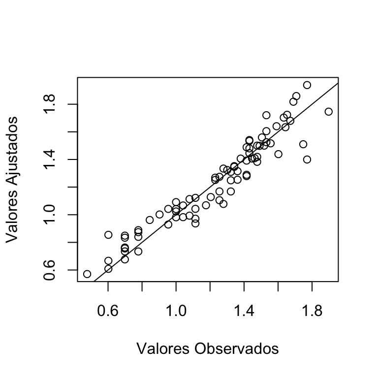

```r
plot(fitted(modelo1) ~ modelo1$model$`log10(riqueza)`, xlab = "Valores Observados", ylab = "Valores Ajustados")
abline(a = 0, b = 1)
```

## Valores Ajustados vs Observados | E se a relação não for boa?

- Considere outro tipo de distribuição para o seu modelo;
- Considere algum tipo de transformação da sua variável resposta;
- Considere incluir mais alguma variável **preditora** na sua análise;
- Plotar os resíduos do seu modelo com outras variáveis preditoras não testadas é uma boa ideia.

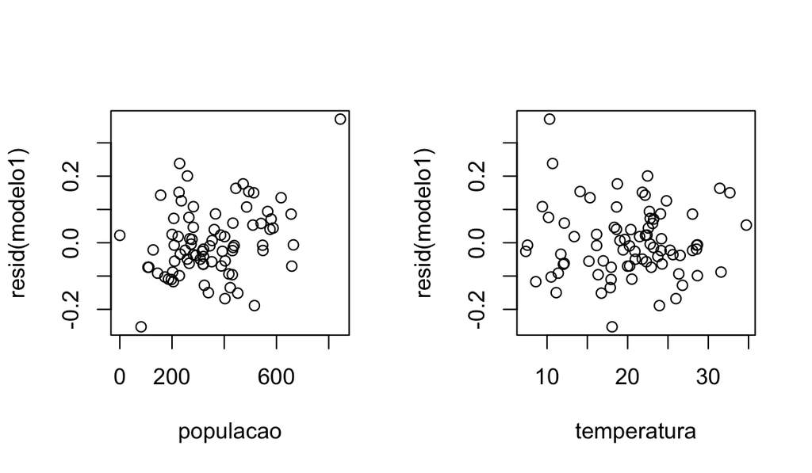

## Variação Residual

- O ruído da relação é conhecida como o *resíduo*: variação na variável resposta que não é explicada pela(s) variável(is) preditora(s).
- **O que você busca?**: uma distribuição dos resíduos próxima a da distribuição normal.

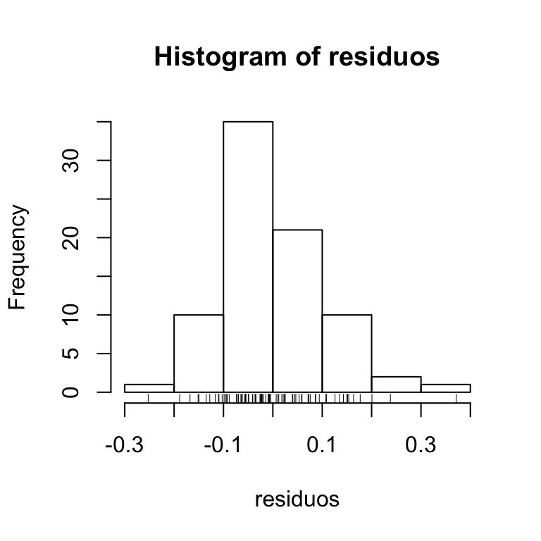

```r
residuos <- resid(modelo1)
hist(residuos);rug(residuos)
```

## Variação Residual | Normalidade dos Resíduos

**Opção 1:** teste estatístico.

```r
residuos <- resid(modelo1)
shapiro.test(residuos)
```

```
##
##  Shapiro-Wilk normality test
##
## data:  residuos
## W = 0.9751, p-value = 0.1201
```

## Variação Residual | Normalidade dos Resíduos

**Opção 2:** visualização gráfica.

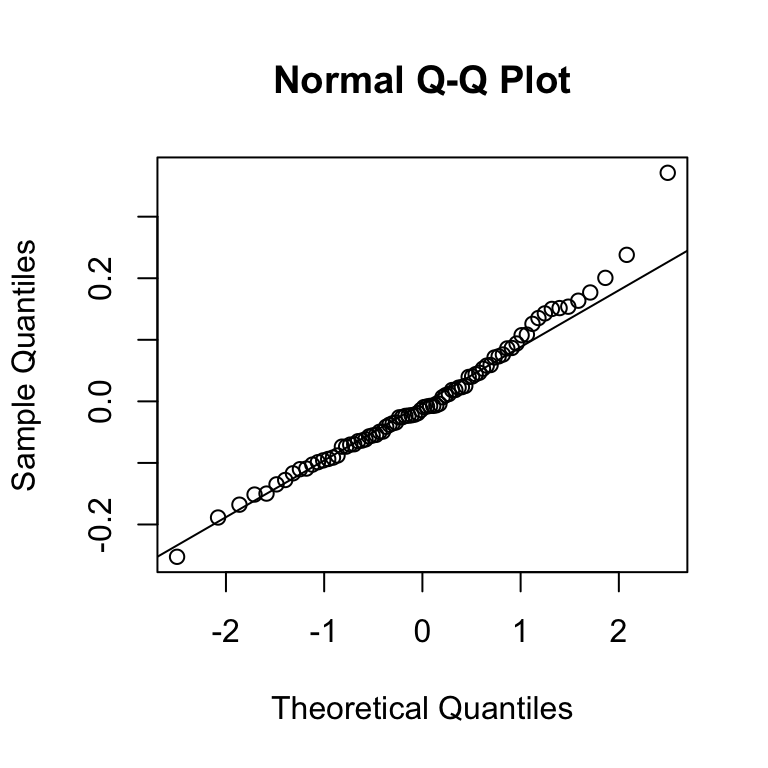

```r
qqnorm(residuos);qqline(residuos)
```

## Variação Residual | Variância dos Resíduos

**Opção 1:** teste estatístico.

```r
bartlett.test(x = residuos, g = ilhas$ilha)
```

```
##
##  Bartlett test of homogeneity of variances
##
## data:  residuos and ilhas$ilha
## Bartlett's K-squared = 1.5782, df = 1, p-value = 0.209
```

```r
bartlett.test(x = residuos, g = ilhas$arquipelago)
```

```
##
##  Bartlett test of homogeneity of variances
##
## data:  residuos and ilhas$arquipelago
## Bartlett's K-squared = 3.5527, df = 2, p-value = 0.1693
```

## Variação Residual | Variância dos Resíduos

**Opção 2:** visualização gráfica.

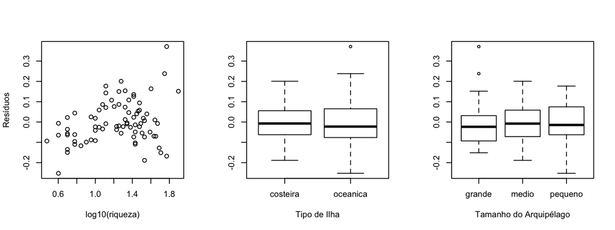

```r
par(mfrow = c(1,3))
plot(residuos ~ log10(riqueza), data = ilhas, ylab = "Resíduos", xlab = "log10(riqueza)")
plot(residuos ~ ilha, data = ilhas, ylab = "", xlab = "Tipo de Ilha")
plot(residuos ~ arquipelago, data = ilhas, ylab = "", xlab = "Tamanho do Arquipélago")
```

## Variação Residual | Relação com os valores ajustados

- **O que você busca?**: os resíduos devem estar espalhados de forma relativamente homogênea com os valores **ajustados**.

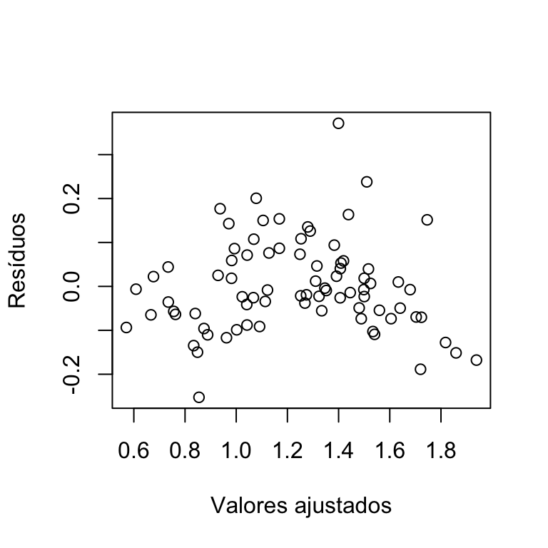

```r
plot(residuos ~ fitted(modelo1), xlab = "Valores ajustados", ylab = "Resíduos")
```

## Variação Residual

- Sempre temos a opção do teste estatístico e da visualização gráfica.
- **Minha recomendação**: use a visualização gráfica.
  - Os testes estatísticos são influenciados pelo tamanho da amostra;
  - Os testes estatísticos são influenciados por outliers;
  - Estes testes estatísticos são sensíveis à desvios na normalidade.

## Variação Residual | E se os resíduos não estiverem conforme?

- Considere outro tipo de distribuição para o seu modelo;
- Use modelos onde estes pressupostos sejam mais flexíveis (`nlme::gls`);
- Plote os resíduos contra as variáveis preditoras usadas, para saber se é alguma mau ajuste à alguma delas.

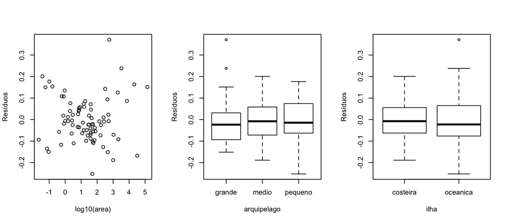

## Independência entre variáveis preditoras

- Algumas das nossas variáveis preditoras podem ter uma forte relação uma com a outra: *colinearidade*;
- Por vezes, o efeito de uma das variáveis preditoras pode ocorrer através de uma relação indireta com outra variável preditora;
- A inclusão de variáveis correlacionadas pode:
  - Reduzir o ajuste do modelo aos dados; e,
  - Inflar a estimativa de variância dos termos - consequência: o do termo efeito na variável resposta some.

## Independência entre variáveis preditoras

- Produtividade e área afetam a riqueza de espécies, mas existe forte colinearidade entre estas variáveis.

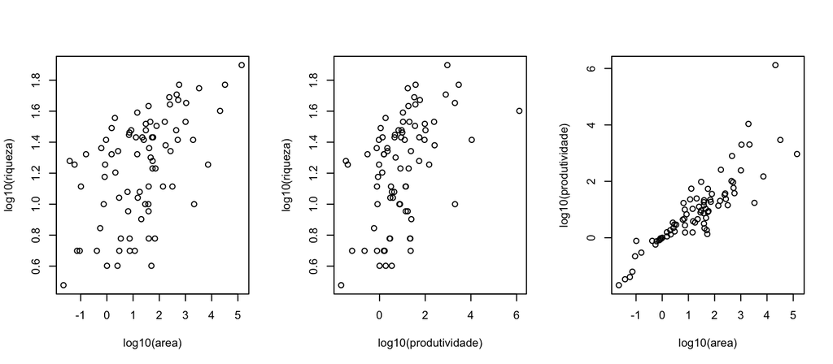

```r
par(mfrow = c(1,3))
plot(log10(riqueza) ~ log10(area), data = ilhas)
plot(log10(riqueza) ~ log10(produtividade), data = ilhas)
plot(log10(produtividade) ~ log10(area), data = ilhas)
```

## Independência entre variáveis preditoras

- A colinearidade é especialmente problemática no contexto de análises multivariadades;
- Além do diagnóstico visual, existe uma métrica para estimar da inflação da variância dos termos do modelo.
- O VIF (Variance Inflation Factor) estima o quanto a variância de um termo é aumentada por conta de colinearidade.
- Você pode calcula o VIF na mão, ou usar a função `car::vif`.

## Independência entre variáveis preditoras

- **O que você busca?**: os valores de VIF devem ser o mais próximo possível de 1.

```r
modelo2 <- glm(log10(riqueza) ~ log10(area) + ilha + arquipelago + log10(produtividade), data = ilhas)
library(car)
vif(modelo2)
```

```
##                          GVIF Df GVIF^(1/(2*Df))
## log10(area)          4.471663  1        2.114631
## ilha                 1.115257  1        1.056057
## arquipelago          1.136759  2        1.032564
## log10(produtividade) 4.443056  1        2.107856
```

```r
vif(modelo1)
```

```
##                 GVIF Df GVIF^(1/(2*Df))
## log10(area) 1.013895  1        1.006923
## ilha        1.114863  1        1.055871
## arquipelago 1.107183  2        1.025782
```

## Independência entre variáveis preditoras | E se houver colinearidade?

- Você pode:
  1. Excluir a variável resposta que menos contribuir para o modelo.
  2. Transformar as variáveis colineares em uma única variável:
     - PCA;
     - k-Means Clustering.

## Influência das observações

- Algumas das suas observações podem ter um peso desproporcional no modelo;
- Existe uma série de métricas disponíveis para avaliar e detectar a influência das observações;
- A função `stats::influence.measures` apresenta várias métricas, dentre as quais se destacam:
  - `cooks.distance` (`car` e `stats`): mede o efeito da remoção de uma determinada observação sobre os coeficientes (**influence**)
  - `stats::hatvalues`: mede o quanto cada observação contribui para o ajuste do modelo (**leverage**)
- O pacote `car` também possui outras funções que ajudam a calcular e visualizar as medidas de influência (por exemplo, `influencePlot`).

## Influência das observações

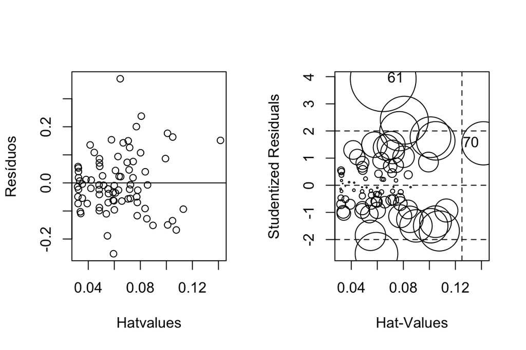

```
##     StudRes        Hat      CookD
## 61 3.924061 0.06452967 0.17822273
## 70 1.545354 0.14154755 0.07732278
```

```r
par(mfrow = c(1,2))
plot(residuos ~ hatvalues(modelo1), xlab = "Hatvalues", ylab = "Resíduos")
abline(a = 0, b = 0)
influencePlot(modelo1)
```

## Influência das observações | E se houver a influência de alguma observação?

- Remover observações simplesmente para melhorar o ajuste do modelo aos dados não é boa prática, a não ser que você tenha uma boa justificativa para tal.
- A remoção da(s) observação(ões) de maior influência é menos problemática quando:
  - observação for um outlier;
  - observação está puxando muito a relação estabelecida pelo modelo.
- Qualquer remoção de várias como estas deve ser reportada de forma clara na análise de dados do seu trabalho.

## Independência entre observações

- Suas observações precisam ser independentes;
- Por exemplo: ao tirar o tempo de um corredor em uma corrida, para determinar sua posição, o ideal é:
  - Ter vários tempos referentes à mesma volta?
  - Ter vários tempos referentes à diferentes voltas?
- Pode acontecer de aparecer uma dependência temporal e/ou espacial no seu modelo, sem que isso tenha sido contemplado pelo seu desenho amostral - existe solução para isso também.
- Existem modelos lineares específicos para observações não independentes (veremos isso mais à frente).

## Considerações finais

- Você pode conseguir os principais plots de diagnóstico e validação de modelos diretamente usando `plot(nome_do_modelo)`.
- O melhor modelo não é somente aquele que se ajusta melhor aos seus dados, mas aquele que também consegui reproduzir os padrões apresentados pelos dados.
- O diagnóstico e validação de modelos é parte mandatória da análise de dados.
- Este processo deve ser conduzido ao mesmo tempo do processo de seleção de modelos: cada modelo criado deve ser diagnosticado e validado antes de ir para a seleção.
- Para quase todos os problemas existe uma solução na análise de dados, mas ela não resolve problemas de desenho amostral/experimental.